# An introduction to resampling and the bootstrap

## Introduction:

For the introductory part of this assignment, I want to define the different data that is further going to be handled. Starting by defining the python packages needed for plotting. Then importing data from a excel file. To spice things up, I defined a loop to find the difference in length between the two sides. The difference in length is what I further use to plot and apply bootstrap methods on.

```python
#Importing the different python packages needed for plotting.
import pandas as pd
import numpy as np
import matplotlib.pyplot as plt
from numpy import random as rnd
```

```python
#Creating a variable called df. This is then used to assign the pandas dataframe with the right directory.
df = pd.read_excel("FaultDisplacement.xlsx")
print(df)
```

```
   experiment_number  FaultNr  side_a  side_b
0              12-14        1     5.0     5.0
1              12-14        2     8.0     8.0
2              12-14        3    16.0    14.0
3              12-14        4     4.0     2.5
4              15-14        1     2.0     2.0
5              15-14        2     3.0     3.0
6              15-14        3     9.0    10.0
7              15-14        4    20.0     8.0
8              15-14        5     4.0     6.0
9              15-14        6     3.0     5.0
10             27-14        1     2.0     2.5
11             27-14        2     5.0     5.0
12             27-14        3    14.5    11.0
13             27-14        4     3.0     3.0
```

[output cut: 16 more lines]

Instead of looking at the difference in fault lengths I decided it would be more resonable to look at the difference. Therefore, the code below was produced to see what the difference in length was.

```python
#Defines a empty list.
difference = []
#Defines a variable that can be set to the difference.
diff_number = 0;

#A loop looping trough the dataframe.
for x in df.itertuples(index=False):
    #Testing if Side A is smaller than Side B.
    if x[2] < x[3]:
        #If Side A is smaller than Side B. Variable diff_number is sett to the difference.
        diff_number = x[3]-x[2]
        #Adds the number to the list.
        difference.append(diff_number)
    #Testing if Side B is smaller than Side A.
    if x[2] > x[3]:
        #If Side B is smaller than Side A. Variable diff_number is sett as the difference.
        diff_number = x[2]-x[3]
        #Adds the number to the list.
        difference.append(diff_number)
    #Testing if Side A and Side B are equal.
    if x[2] == x[3]:
        #If the sides are equal. The difference is zero, hence the viariable is set as zero.
        diff_number = 0;
        #Adds the number to the list.
        difference.append(diff_number)
#Prints the list.
print (difference)
```

```
[0, 0, 2.0, 1.5, 0, 0, 1.0, 12.0, 2.0, 2.0, 0.5, 0, 3.5, 0, 1.0, 2.0, 8.0, 3.0, 9.0, 1.0, 2.0, 8.0, 3.0, 9.0, 3.0, 1.0, 2.0, 1.0, 4.0, 11.0]
```

1. Plot a histogram of your sample, and give a short description

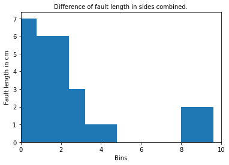

```python
#Plots a histogram taking the difference between the sides, putting it into 15 bins.
plt.hist(difference, 15)

#Adjusting axis size.
plt.tick_params(axis="x", labelsize=10)
plt.tick_params(axis="y", labelsize=10)

#Setting the limits on the x-axis.
plt.xlim(0,10)

#Adding title and axis names.
plt.title("Difference of fault length in sides combined.", fontsize = 10)
plt.xlabel("Bins")
plt.ylabel("Fault length in cm")
#Shows the plot.
plt.show()
```

## Methods:

1. Generate a bootstrap sample and plot it on the same histogram as the original sample.

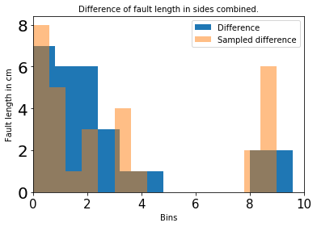

```python
#Setting n = 30.
n = 30;

#Using rnd.choice to make a bootrstap of difference with the dimensions (difference x n)
new_difference = rnd.choice(difference,n)

#Plotting difference
plt.hist(difference, 15, label = 'Difference')

#Plotting the sampled difference created above from rnd.choice.
plt.hist(new_difference,15, label='Sampled difference', alpha =0.5)

#Adding legend.
plt.legend(frameon=True);

#Adjusting axis size.
plt.tick_params(axis="x", labelsize=15)
plt.tick_params(axis="y", labelsize=20)

#Setting the limits on the x-axis.
plt.xlim(0,10)

#Adding title and axis names.
plt.title("Difference of fault length in sides combined.", fontsize = 10)
plt.xlabel("Bins")
plt.ylabel("Fault length in cm")

#Shows the plot.
plt.show()
```

Generate a large bootstrap distribution of the sample mean and plot it as a histogram.</br> Below a boostrap distribution has been generated of the sample mean. It has also been plotted with the approach, which can be seen below.

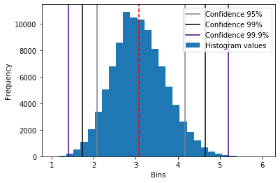

```python
#Creating a n_boot variable and setting it to be 10^5
n_boot = 10**5

#Defining a variable that is set to be the difference with a dimension of n x n_boot.
array = rnd.choice(difference, size = (n, n_boot))

#Defining boot_mean. Setting it to be the mean value of what has been calculated above.
boot_mean = np.mean(array, axis = 0)


#Adding a line to represent the mean of the calculations done above.
plt.axvline(array.mean(), color = 'red', linestyle = 'dashed')

#Adding lines to show 95%, 99% and 99,9% confidence intervals.
plt.axvline(np.quantile(boot_mean, 0.95), color= 'grey', label='Confidence 95%')
plt.axvline(np.quantile(boot_mean, 0.05), color= 'grey')
plt.axvline(np.quantile(boot_mean, 0.99), color= 'black', label='Confidence 99%')
plt.axvline(np.quantile(boot_mean, 0.01), color= 'black')
plt.axvline(np.quantile(boot_mean, 0.999), color= 'indigo', label='Confidence 99.9%')
plt.axvline(np.quantile(boot_mean, 0.001), color= 'indigo')

#Plotting the histogram, with 30 bins.
ax = plt.hist(boot_mean, 30, label = "Histogram values")

#Adding legend and labels on axis.
plt.xlabel("Bins")
plt.ylabel("Frequency")
plt.legend()

#Showing the plot.
plt.show()
```

## Results:

```python
print(np.quantile(boot_mean, 0.95))
print(np.quantile(boot_mean, 0.05))
```

```
4.166666666666667
2.0833333333333335
```

```python
print(np.quantile(boot_mean, 0.99))
print(np.quantile(boot_mean, 0.01))
```

```
4.666666666666667
1.75
```

```python
print(np.quantile(boot_mean, 0.999))
print(np.quantile(boot_mean, 0.001))
```

```
5.183333333333334
1.4
```

1. Repeat the computation of a bootstrap distribution and confidence intervals four more times, but each time reducing the number of observations used in the bootstrap samples. Produce a simple plot to visualize how the width of the confidence interval changes as sample size decreases.

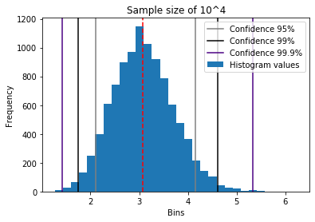

```python
n_boot = 10**4
#Defining a variable that is set to be the difference with a dimension of n x n_boot.
array = rnd.choice(difference, size = (n, n_boot))

#Defining boot_mean. Setting it to be the mean value of what has been calculated above.
boot_mean = np.mean(array, axis = 0)


#Adding a line to represent the mean of the calculations done above.
plt.axvline(array.mean(), color = 'red', linestyle = 'dashed')

#Adding lines to show 95%, 99% and 99,9% confidence intervals.
plt.axvline(np.quantile(boot_mean, 0.95), color= 'grey', label='Confidence 95%')
plt.axvline(np.quantile(boot_mean, 0.05), color= 'grey')
plt.axvline(np.quantile(boot_mean, 0.99), color= 'black', label='Confidence 99%')
plt.axvline(np.quantile(boot_mean, 0.01), color= 'black')
plt.axvline(np.quantile(boot_mean, 0.999), color= 'indigo', label='Confidence 99.9%')
plt.axvline(np.quantile(boot_mean, 0.001), color= 'indigo')

#Plotting the histogram, with 30 bins.
ax = plt.hist(boot_mean, 30, label = "Histogram values")



#Adding title
plt.title("Sample size of 10^4")

#Adding legend and labels on axis.
plt.xlabel("Bins")
plt.ylabel("Frequency")
plt.legend()


#Showing the plot.
plt.show()
```

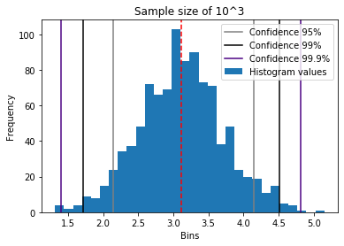

```python
n_boot = 10**3
#Defining a variable that is set to be the difference with a dimension of n x n_boot.
array = rnd.choice(difference, size = (n, n_boot))

#Defining boot_mean. Setting it to be the mean value of what has been calculated above.
boot_mean = np.mean(array, axis = 0)


#Adding a line to represent the mean of the calculations done above.
plt.axvline(array.mean(), color = 'red', linestyle = 'dashed')

#Adding lines to show 95%, 99% and 99,9% confidence intervals.
plt.axvline(np.quantile(boot_mean, 0.95), color= 'grey', label='Confidence 95%')
plt.axvline(np.quantile(boot_mean, 0.05), color= 'grey')
plt.axvline(np.quantile(boot_mean, 0.99), color= 'black', label='Confidence 99%')
plt.axvline(np.quantile(boot_mean, 0.01), color= 'black')
plt.axvline(np.quantile(boot_mean, 0.999), color= 'indigo', label='Confidence 99.9%')
plt.axvline(np.quantile(boot_mean, 0.001), color= 'indigo')

#Plotting the histogram, with 30 bins.
ax = plt.hist(boot_mean, 30, label = "Histogram values")


#Adding title
plt.title("Sample size of 10^3")


#Adding legend and labels on axis.
plt.xlabel("Bins")
plt.ylabel("Frequency")
plt.legend()

#Showing the plot.
plt.show()
```

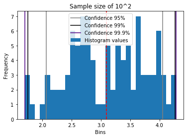

```python
n_boot = 10**2
#Defining a variable that is set to be the difference with a dimension of n x n_boot.
array = rnd.choice(difference, size = (n, n_boot))

#Defining boot_mean. Setting it to be the mean value of what has been calculated above.
boot_mean = np.mean(array, axis = 0)


#Adding a line to represent the mean of the calculations done above.
plt.axvline(array.mean(), color = 'red', linestyle = 'dashed')

#Adding lines to show 95%, 99% and 99,9% confidence intervals.
plt.axvline(np.quantile(boot_mean, 0.95), color= 'grey', label='Confidence 95%')
plt.axvline(np.quantile(boot_mean, 0.05), color= 'grey')
plt.axvline(np.quantile(boot_mean, 0.99), color= 'black', label='Confidence 99%')
plt.axvline(np.quantile(boot_mean, 0.01), color= 'black')
plt.axvline(np.quantile(boot_mean, 0.999), color= 'indigo', label='Confidence 99.9%')
plt.axvline(np.quantile(boot_mean, 0.001), color= 'indigo')

#Plotting the histogram, with 30 bins.
ax = plt.hist(boot_mean, 30, label = "Histogram values")


#Adding title
plt.title("Sample size of 10^2")

#Adding legend and labels on axis.
plt.xlabel("Bins")
plt.ylabel("Frequency")
plt.legend()

#Showing the plot.
plt.show()
```

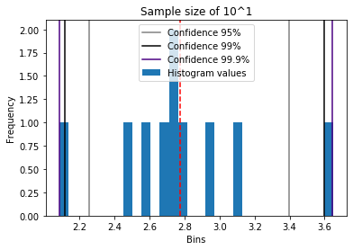

```python
n_boot = 10
#Defining a variable that is set to be the difference with a dimension of n x n_boot.
array = rnd.choice(difference, size = (n, n_boot))

#Defining boot_mean. Setting it to be the mean value of what has been calculated above.
boot_mean = np.mean(array, axis = 0)


#Adding a line to represent the mean of the calculations done above.
plt.axvline(array.mean(), color = 'red', linestyle = 'dashed')

#Adding lines to show 95%, 99% and 99,9% confidence intervals.
plt.axvline(np.quantile(boot_mean, 0.95), color= 'grey', label='Confidence 95%')
plt.axvline(np.quantile(boot_mean, 0.05), color= 'grey')
plt.axvline(np.quantile(boot_mean, 0.99), color= 'black', label='Confidence 99%')
plt.axvline(np.quantile(boot_mean, 0.01), color= 'black')
plt.axvline(np.quantile(boot_mean, 0.999), color= 'indigo', label='Confidence 99.9%')
plt.axvline(np.quantile(boot_mean, 0.001), color= 'indigo')

#Plotting the histogram, with 30 bins.
ax = plt.hist(boot_mean, 30, label = "Histogram values")

#Adding title
plt.title("Sample size of 10^1")

#Adding legend and labels on axis.
plt.xlabel("Bins")
plt.ylabel("Frequency")
plt.legend()

#Showing the plot.
plt.show()
```

6.2 Produce a simple plot to visualize how the width of the confidence interval changes as sample size decreases. </br>

```python
n_boot = 10**5
#Defining a variable that is set to be the difference with a dimension of n x n_boot.
array = rnd.choice(difference, size = (n, n_boot))
#Defining boot_mean. Setting it to be the mean value of what has been calculated above.
boot_mean = np.mean(array, axis = 0)

#Adding the widths to a list
list_1 = [(np.quantile(boot_mean, 0.95) - np.quantile(boot_mean, 0.05)),
          (np.quantile(boot_mean, 0.99) - np.quantile(boot_mean, 0.01)),
          (np.quantile(boot_mean, 0.999) - np.quantile(boot_mean, 0.001))]
print(list_1)
```

```
[2.0500000000000003, 2.8833333333333337, 3.8333333333333335]
```

```python
n_boot = 10**4
#Defining a variable that is set to be the difference with a dimension of n x n_boot.
array = rnd.choice(difference, size = (n, n_boot))
#Defining boot_mean. Setting it to be the mean value of what has been calculated above.
boot_mean = np.mean(array, axis = 0)

#Adding the widths to a list
list_2 = [(np.quantile(boot_mean, 0.95) - np.quantile(boot_mean, 0.05)),
          (np.quantile(boot_mean, 0.99) - np.quantile(boot_mean, 0.01)),
          (np.quantile(boot_mean, 0.999) - np.quantile(boot_mean, 0.001))]
print(list_2)
```

```
[2.0333333333333337, 2.85016666666667, 3.6500333333333366]
```

```python
n_boot = 10**3
#Defining a variable that is set to be the difference with a dimension of n x n_boot.
array = rnd.choice(difference, size = (n, n_boot))
#Defining boot_mean. Setting it to be the mean value of what has been calculated above.
boot_mean = np.mean(array, axis = 0)

#Adding the widths to a list
list_3 = [(np.quantile(boot_mean, 0.95) - np.quantile(boot_mean, 0.05)),
          (np.quantile(boot_mean, 0.99) - np.quantile(boot_mean, 0.01)),
          (np.quantile(boot_mean, 0.999) - np.quantile(boot_mean, 0.001))]
print(list_3)
```

```
[2.0333333333333328, 2.917333333333333, 3.4171833333333255]
```

```python
n_boot = 10**2
#Defining a variable that is set to be the difference with a dimension of n x n_boot.
array = rnd.choice(difference, size = (n, n_boot))
#Defining boot_mean. Setting it to be the mean value of what has been calculated above.
boot_mean = np.mean(array, axis = 0)

#Adding the widths to a list
list_4 = [(np.quantile(boot_mean, 0.95) - np.quantile(boot_mean, 0.05)),
          (np.quantile(boot_mean, 0.99) - np.quantile(boot_mean, 0.01)),
          (np.quantile(boot_mean, 0.999) - np.quantile(boot_mean, 0.001))]
print(list_4)
```

```
[1.81, 2.6861666666666686, 2.9386166666666664]
```

```python
n_boot = 10
#Defining a variable that is set to be the difference with a dimension of n x n_boot.
array = rnd.choice(difference, size = (n, n_boot))
#Defining boot_mean. Setting it to be the mean value of what has been calculated above.
boot_mean = np.mean(array, axis = 0)

#Adding the widths to a list
list_5 = [(np.quantile(boot_mean, 0.95) - np.quantile(boot_mean, 0.05)),
          (np.quantile(boot_mean, 0.99) - np.quantile(boot_mean, 0.01)),
          (np.quantile(boot_mean, 0.999) - np.quantile(boot_mean, 0.001))]
print(list_5)
```

```
[1.669999999999999, 2.0540000000000003, 2.140399999999999]
```

```python
complete_list = (list_1,list_2,list_3,list_4,list_5)
```

```python
complete_list
```

```
([2.0500000000000003, 2.8833333333333337, 3.8333333333333335],
 [2.0333333333333337, 2.85016666666667, 3.6500333333333366],
 [2.0333333333333328, 2.917333333333333, 3.4171833333333255],
 [1.81, 2.6861666666666686, 2.9386166666666664],
 [1.669999999999999, 2.0540000000000003, 2.140399999999999])
```

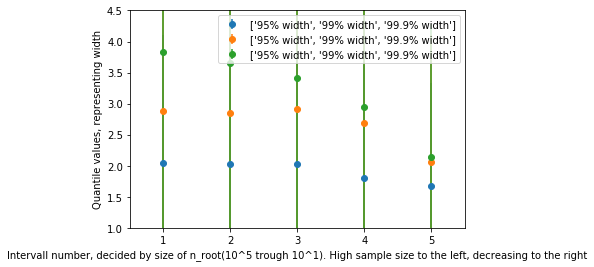

```python
x = [1,2,3,4,5]
y = complete_list
plt.xlabel("Intervall number, decided by size of n_root(10^5 trough 10^1)."+
           " High sample size to the left, decreasing to the right")
plt.ylabel("Quantile values, representing width")
plt.title("")
plt.ylim(1,4.5)
plt.xlim(0.5,5.5)
for i in range(len(y[0])):
    plt.errorbar(x, [pt[i] for pt in y], yerr=[pt[i] for pt in y], fmt='o',
                 label =["95% width","99% width","99.9% width"])
plt.legend()
plt.show()
```

#### Discussion:

As can be seen in the plot above. The width is greatest for the mean that have the highest sample size. As it moves to 10^1 the width decreases. Since we are generating a bootstrap in this assignment the values will differ each time the code is ran. However, the general result of the approach is the same as it is run through.

#### Conclusion:

In this assignment we have learnt how to apply bootstrapping and sampling techniques on our own data. Fault data was a good fit for this assignment. Since there was not many values in the dataset the approach was fast to run in Python 3.0.